# PD-1 pneumonitis Dataset analysis: Incidence, Risk Factors, Survival

# Time to Onset Analysis

This is to reproduce time to onset as described previously (Naidoo et al JCO) for other PD-1 pneumonitis datasets

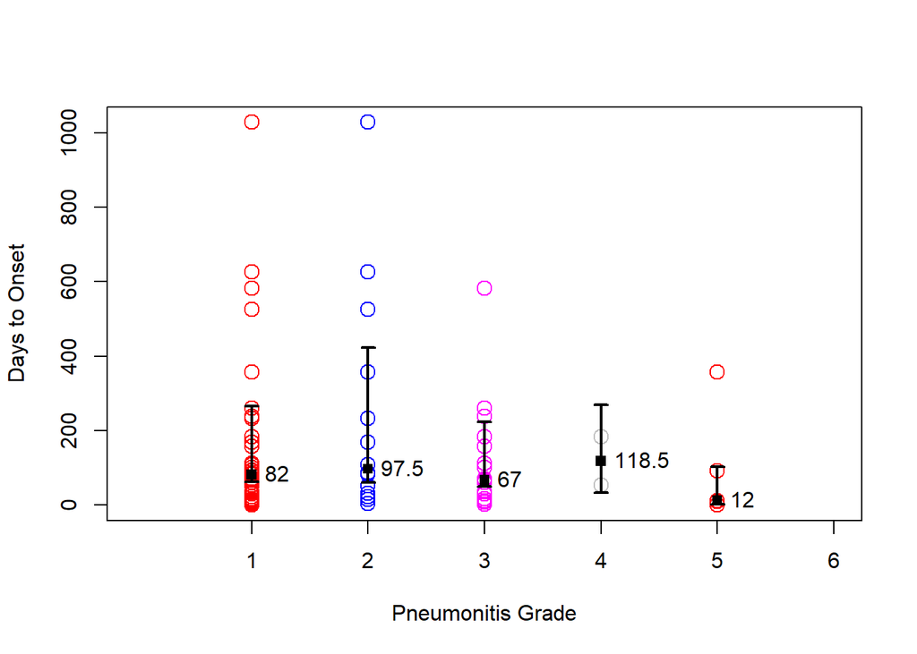

```r
#-----------------------------------------------------------------

# Time to onset analysis - written 12/13/2017

# we create date to onset by subtracting therapy initiation date from pneumonitis onset date
PneumonitisPts$DaystoOnset <- as.Date(PneumonitisPts$Pneumonitis.Start.Date, format="%m/%d/%Y")-as.Date(PneumonitisPts$First.IO.Treatment.Start.Date.PD.1.PD.L1...manual.update, format="%m/%d/%Y")

# create a concatenated list to plot all patients followed by patients by grade
OnsetByGrade <- cbind(PneumonitisPts$Highest.Pneumonitis.Grade, PneumonitisPts$DaystoOnset)
OnsetTotal <- cbind(PneumonitisPts$Any.Grade.Pneumonitis..Y.1..N.0., PneumonitisPts$DaystoOnset)
OnsetTotal <- rbind(OnsetTotal, OnsetByGrade)
OnsetTotal <- as.data.frame(OnsetTotal)

# get rid of the unknown column (i.e grade ="6")
OnsetTotal <- OnsetTotal[OnsetTotal$V1 < 6,]

# in OnsetTotal, V1 = Grade (1 = all), V2 = days

#calculate mean and median time to onset by grade as well as SD and SEM
MeanTimeToOnset <- aggregate(OnsetTotal$V2, by=list(V1=OnsetTotal$V1), FUN=mean)
MedianTimeToOnset <- aggregate(OnsetTotal$V2, by=list(V1=OnsetTotal$V1), FUN=median)
IQRTimeToOnset <- as.matrix(aggregate(OnsetTotal$V2, by=list(V1=OnsetTotal$V1), FUN=quantile))
NumPerGrade <- aggregate(OnsetTotal$V2, by=list(V1=OnsetTotal$V1), FUN=length)
IQRLower <- as.data.frame(IQRTimeToOnset[,3])
colnames(IQRLower) <- c("x")
IQRHigher <- as.data.frame(IQRTimeToOnset[,5])
colnames(IQRHigher) <- c("x")

# plot time to onset. Grade "1" = all grades
plotOnset <- function() {
plot(OnsetTotal$V1, OnsetTotal$V2, ylab="Days to Onset", xlab="Pneumonitis Grade", xaxt="n", col=OnsetTotal$V1*10, pch=1, cex=1.5, xlim=c(0,6))

axis(1, at=1:6)
# add medians
points(MedianTimeToOnset, pch=15,bg="red")
# add error bars
arrows(as.integer(MedianTimeToOnset$V1),  MedianTimeToOnset$x- IQRLower$x, as.integer(MedianTimeToOnset$V1), MedianTimeToOnset$x+IQRHigher$x, lwd = 2, angle = 90,code = 3, length = 0.05)
text(MedianTimeToOnset, labels=MedianTimeToOnset$x, pos=4, offset=0.5, cex=1)
}

plotOnset()
```

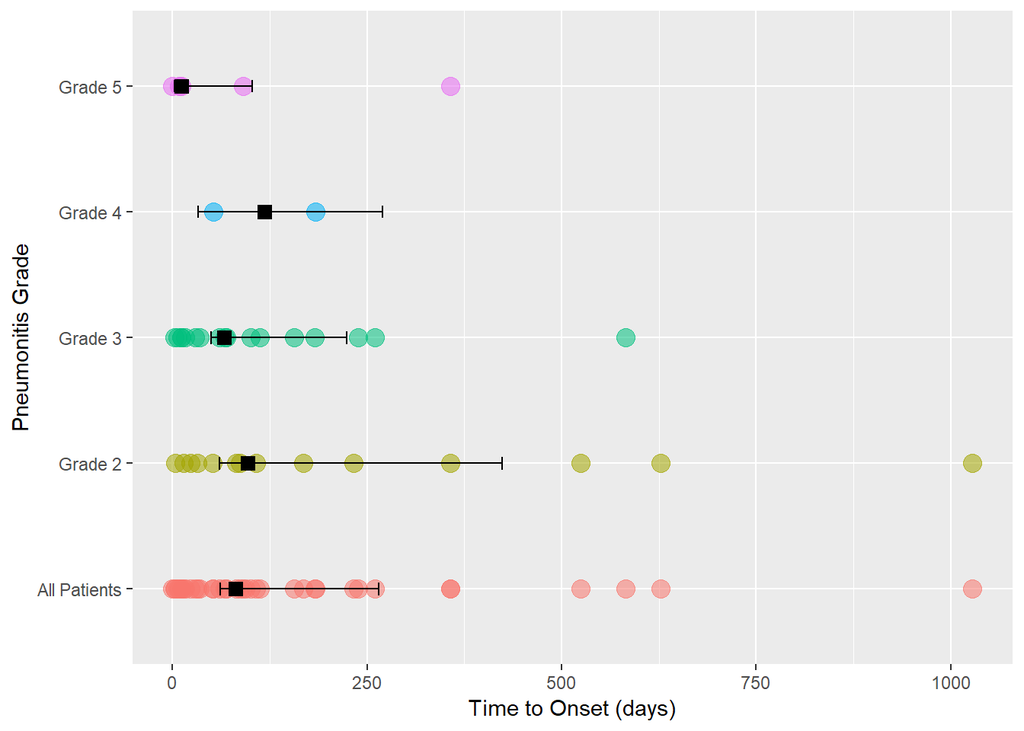

```r
ggplotOnset<- as.data.frame(cbind(MedianTimeToOnset, IQRLower, IQRHigher))
colnames(ggplotOnset)=c("Grade", "Median", "IQR.Low", "IQR.High")
OnsetTotal$V1 <- as.factor(OnsetTotal$V1)
levels(OnsetTotal$V1) <- c("All Patients", "Grade 2", "Grade 3", "Grade 4", "Grade 5")
# lets make a ggplot2 version of this graph
ggplot(OnsetTotal, aes(x=V1, y=V2))+geom_point(size=4, aes(color=factor(V1), alpha=0.1))+labs(x="Pneumonitis Grade", y="Time to Onset (days)")+geom_point(data=ggplotOnset, aes(x=Grade, y=Median), shape=15, size=3)+geom_errorbar(data=ggplotOnset, aes(x=Grade, ymin=Median-IQR.Low, ymax=Median+IQR.High), inherit.aes=FALSE, width=0.1)+theme(legend.position="none")+coord_flip()
```

```r
# look just at worsened patients
WorsenedPts <<- PneumonitisPts[!is.na(PneumonitisPts$Additional.Immunosuppression..Y.1..N.0.) & PneumonitisPts$Additional.Immunosuppression..Y.1..N.0.==1,]
WorsenedPts <- WorsenedPts[-c(1:5,9,10,12,14)]
```

# Pneumonitis Incidence by Year

```r
#---------pneumonitis incidence by year: coded 12/14/17--------------------
# pull out just the year for pneumonitis start date and grade of pneumonitis from the PneumonitisPts

library(data.table)
library(lubridate)
```

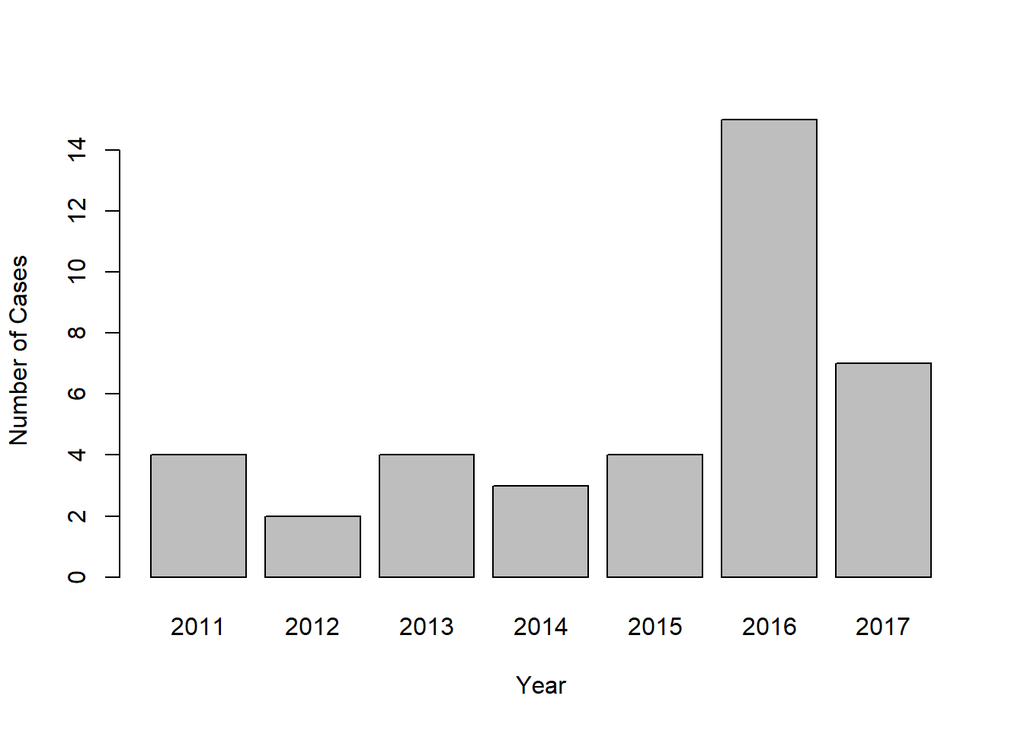

```r
PneumonitisByYear <- as.data.frame(cbind(as.character(PneumonitisPts$Pneumonitis.Start.Date), PneumonitisPts$Highest.Pneumonitis.Grade))
colnames(PneumonitisByYear) <- c("Year", "Grade")
PneumonitisByYear$Year <- year(as.Date(PneumonitisByYear$Year, format ="%m/%d/%Y"))
PneumonitisIncidenceByYear <- aggregate(PneumonitisByYear$Grade, by=list(Year=PneumonitisByYear$Year), FUN=length)
barplot(PneumonitisIncidenceByYear$x, names.arg=PneumonitisIncidenceByYear$Year, xlab="Year", ylab="Number of Cases")
```

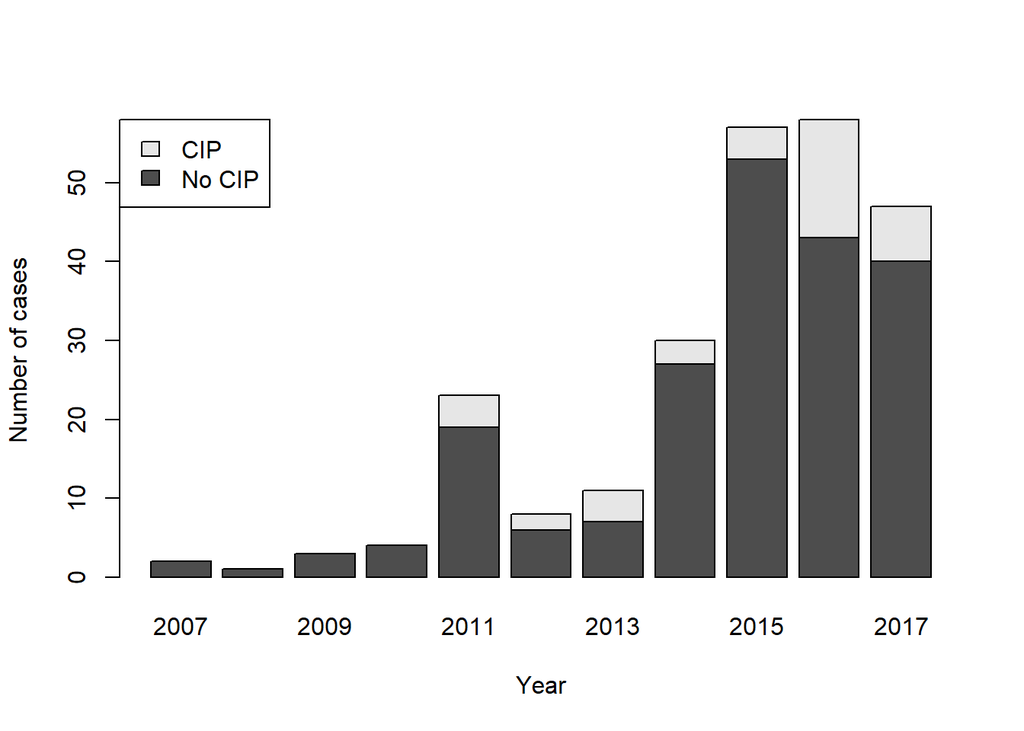

```r
# so, the issue here is that more cases were picked up in the last 2 years

# let's do the same for all CA patients (The entire PD1_df data frame)
AllPtsByYear <- as.data.frame(year(as.Date(as.character(PD1_df$First.IO.Treatment.Start.Date.PD.1.PD.L1...manual.update), format="%m/%d/%Y")))
colnames(AllPtsByYear) <- c("Year")
AllIncidenceByYear <- aggregate(AllPtsByYear$Year, by=list(Year=AllPtsByYear$Year), FUN=length)


# inner join All patients and pneumonitis patients to create a stacked bar plot
# note for the inner join here, i renamed the year column as 'Year' for both Dfs. You don't have to do that, by = c(name1, name2) will match name1 in df_1 to name2 in df_2

# now, there are more years in the total dataset than in the pneumonitis dataset, so we can't do a inner_join. We'll have to do a one sided left_join, the years where no pneumonitis incidence data is available will be NAs
CombinedIncidenceByYear <- left_join(AllIncidenceByYear, PneumonitisIncidenceByYear,by="Year")

# some gymnastics to get this into stacked bar plotform
CombinedIncidenceByYear <- as.data.frame(transpose(CombinedIncidenceByYear))
colnames(CombinedIncidenceByYear) = CombinedIncidenceByYear[1,]
CombinedIncidenceByYear=CombinedIncidenceByYear[-1,]
barplot(as.matrix(CombinedIncidenceByYear), xlab="Year", ylab="Number of cases", legend.text=c("No CIP", "CIP"), args.legend=list(x="topleft"))
```

```r
# ggplot version
```

# Modeling: Cox PH and Logistic Regression Models

Now the meat of the matter. We want to look at survival differences between patients with and without pneumonitis using univariate (Kaplan-Meier) and multivariate (COx PH Regression) methods. For this, though, we need to first clean up our data significantly. We are doing 2 COX PH models: one for development of pneumonitis (outcome: pneumonitis) and one for survival (outcome: death). The problem with looking at the relationship between pneumonitis and death is that Cox PH mandates that the covariates must be defined at the onset and doing a Kaplan Meier based on pneumonitis disobeyes this rule. So, we will use landmark analysis.

## 1. Data cleanup for Cox PH REgression analysis

```r
#--------Survival analysis for pneumonitis vs. no pneumonitis, written 12/14/17, r2: 01/22/18--------------------
# As of 01.24.2017, we have fully updated the alive/last follow-up column and vital stats
# Update 02/2018: We will plan on doing two sets of analysis: one is a CoxPH for risk factors for developing pneumonitis. The second is the survival analysis we have already coded.
# To get the time to onset, this has already been calculated for the time to onset analysis above. We will left join the LR_df with the PneumonitisPts_df to bring in these dates.

# lets look at # alive/dead in pneumonitis vs. non-pneumonitis
# pneumonitis patients
aggregate(PneumonitisPts$Vital.Status..Alive.1..Dead.0., by=list(Vital.Status..Alive.1..Dead.0.= PneumonitisPts$Vital.Status..Alive.1..Dead.0.), FUN=length)
```

| Vital.Status..Alive.1..Dead.0. | x |
| --- | --- |
| Alive | 13 |
| Deceased | 26 |

```r
# non-pneumonitis patients
aggregate(NoPneumonitisPts$Vital.Status..Alive.1..Dead.0., by=list(Vital.Status..Alive.1..Dead.0.= NoPneumonitisPts$Vital.Status..Alive.1..Dead.0.), FUN=length)
```

| Vital.Status..Alive.1..Dead.0. | x |
| --- | --- |
| Alive | 105 |
| Deceased | 61 |

```r
#--------------Data Prep for  Regression------------------01/30/2018-------------
#-----------Update 02/2018: Add additional calculated time_to_pneumonitis_onset
LR_df<<-PD1_df
RemoveNAPneumonitisOnset <- function (x) {
  if(is.na(x)) return(0)
  else return(1)
}
LR_df$Any.Grade.Pneumonitis..Y.1..N.0. <- lapply(LR_df$Any.Grade.Pneumonitis..Y.1..N.0., RemoveNAPneumonitisOnset)

# add time to onset for pneumonitis, which is the time variable for the censor variable Pneumonitis (coded above)
# make a df containing only MRN and date to pneumonitis onset
PneumonitisOnset_df <- as.data.frame(cbind(PneumonitisPts$MRN, PneumonitisPts$DaystoOnset))
colnames(PneumonitisOnset_df) <- c("MRN", "PneumonitisOnset")
LR_df <- left_join(LR_df, PneumonitisOnset_df, by="MRN")
# note to "de-level" a factor, needto go to char first
LR_df$PneumonitisOnset <- as.numeric(as.character(LR_df$PneumonitisOnset))
# for the patients who don't have pneumonitis, "time to onset " is never - Last follow-up - treatment initiation date
OnsetDateforNoPneumonits <- function (x) {
  if(is.na(LR_df$PneumonitisOnset[x])){
   LR_df$PneumonitisOnset[x] <<- (as.Date(LR_df$Date.of.Death.or.Last.Follow.up[x], format="%m/%d/%Y")-as.Date(LR_df$First.IO.Treatment.Start.Date.PD.1.PD.L1...manual.update[x], format="%m/%d/%Y"))
   return(x)
  }
  return(x)


}

LR_df$Index <- lapply(LR_df$Index, OnsetDateforNoPneumonits)

FillInComboTx <- function(x) {
  if(LR_df$First.IO.treatment..Secondary..Agent[x]=="" | is.na(LR_df$First.IO.treatment..Secondary..Agent[x])) LR_df$Mono.vs..Combo..0.mono..1.combo.[x]<<-0
  else LR_df$Mono.vs..Combo..0.mono..1.combo.[x]<<-1
  return(x)
 }

LR_df$Index <- lapply(LR_df$Index, FillInComboTx)

FillInSmokingStatus<- function(x) {
  if(x=="Current") return(2)
  if(x=="Former") return(1)
  if(x=="Never") return(0)
}
LR_df$Smoking.Status..0.never..1.former.current..3.unknown. <- lapply(LR_df$Smoking.Status, FillInSmokingStatus)

FillInSmokingYrs <- function (x) {
  if(x=="n/a") return(0)
  else return(x)
}
LR_df$Smoking.Pack.Years <- lapply(LR_df$Smoking.Pack.Years, FillInSmokingYrs)

RecodeVitalStatus <- function(x) {
  if(x=="Alive") return(1)
  if(x=="Deceased") return(0)
}
LR_df$Vital.Status..Alive.1..Dead.0. <- lapply(LR_df$Vital.Status..Alive.1..Dead.0., RecodeVitalStatus)

# these are variables created for the survival analysis

LR_df$censor_status = 1
LR_df$time_to_death = difftime(as.Date(LR_df$Date.of.Death.or.Last.Follow.up, format="%m/%d/%Y"), as.Date(LR_df$First.IO.Treatment.Start.Date.PD.1.PD.L1...manual.update, format="%m/%d/%Y"), units="days")

# this is tricky: The Vital status is coded as Alive=1, Dead=0; censor is coded as: Alive=0, Dead=1
CreateLRCensor <- function (x) {
  if(LR_df$Vital.Status..Alive.1..Dead.0.[x]==1) {
      return(0)
    }
  else return(1)
}

LR_df$Highest.Pneumonitis.Grade <- lapply(LR_df$Highest.Pneumonitis.Grade, function(x) if(x=="") return(0) else return(x))

LR_df$censor_status <- lapply(LR_df$Index, CreateLRCensor)

# validate our censor variable. Alive and censor_status are disjoint sets. When Alive==1, censor==0 and vice versa. So, checking for equality should return all FALSE.

summary(as.numeric(LR_df$Vital.Status..Alive.1..Dead.0.)==as.numeric(LR_df$censor_status))
```

```
##    Mode   FALSE
## logical     205
```

```r
CoxPHModel_df <- LR_df[,c(6,7,9,10,11,12,13,15,16,17,18,22,23,24,25,33,36,40,42,43,44,52,53,54, 55)]
colnames(CoxPHModel_df) <- c("Sex", "Race", "Smoking", "Pk.Years", "Alive", "Death.Or.Last.Follow.Up", "Histology", "Initial.Stage", "Surgery", "Radiation","Chemo", "Combination.ICI", "Immunotherapy.Start.Date", "Immunotherapy.Drug", "Second.Immunotherapy.Drug", "Pneumonitis","Pneumonitis.Grade", "Pneumonitis.Recurrent", "Pneumonitis.Outcome", "Pneumonitis.SecondLineTx", "Pneumonitis.SecondLineDrug", "age", "PneumonitisOnset", "censor", "time_to_death")

# make things numeric. The as.character bit is so that when we convert to numeric, we want the actual value, not factor level.
CoxPHModel_df$Smoking <- as.numeric(as.character(CoxPHModel_df$Smoking))
CoxPHModel_df$Pk.Years<-as.numeric(as.character(CoxPHModel_df$Pk.Years))
CoxPHModel_df$Surgery <- as.numeric(as.character(CoxPHModel_df$Surgery))
CoxPHModel_df$Combination.ICI <-as.numeric(as.character(CoxPHModel_df$Combination.ICI))
CoxPHModel_df$Pneumonitis <- as.numeric(as.character(CoxPHModel_df$Pneumonitis))
CoxPHModel_df$censor<- as.numeric(as.character(CoxPHModel_df$censor))
CoxPHModel_df$time_to_death <- as.numeric(as.character(CoxPHModel_df$time_to_death))
CoxPHModel_df$Alive <- as.numeric(as.character(CoxPHModel_df$Alive))
CoxPHModel_df$Chemo <- as.numeric(as.character(CoxPHModel_df$Chemo))
CoxPHModel_df$PneumonitisOnset <- as.numeric(as.character(CoxPHModel_df$PneumonitisOnset))
CoxPHModel_df$Pneumonitis.Grade <- as.numeric(as.character(CoxPHModel_df$Pneumonitis.Grade))
CoxPHModel_df$age <- as.numeric(as.character(CoxPHModel_df$age))
# get rid of extra levels for Sex
levels(CoxPHModel_df$Sex) <- list(Male="M", Male="m", Female="F")

levels(CoxPHModel_df$Pneumonitis.Grade) = list("0"=0,"1"=1,"2"=2,"3"=3,"4"=4,"5"=5)
# level CA Initial Stage  properly
levels(CoxPHModel_df$Initial.Stage) <- list(IV="IV", I = "I", I ="1B", II ="II", III ="III")

# level race,
levels(CoxPHModel_df$Race) = list(W="w", W="W", B="B", O="A", O="M", O="O")

# flatten immunotherapy drug
ICIDrugCode <- function(x) {

  if(x=="Nivolumab") return(1)
  if(x=="Pembrolizumab") return(2)
  else(return(3))
}

CoxPHModel_df$Immunotherapy.Drug.Recode <- lapply(CoxPHModel_df$Immunotherapy.Drug, ICIDrugCode)
CoxPHModel_df$Immunotherapy.Drug.Recode <- as.factor(as.numeric(as.character(CoxPHModel_df$Immunotherapy.Drug.Recode)))
# level histology
levels(CoxPHModel_df$Histology) <- list(Adenocarcinoma="Adenocarcinoma", Adenocarcinoma="Adenosquamous carcinioma", Other="Atyical carcinoid", Other="Carcinoma", Other="Poorly differentiated carcinoma", Other="Large cell neuroendocrine carcinoma", Other="Mesothelioma",  Squamous="Squamous cell carcinoma", Other="Sarcomatoid carcinoma", Other="Small Cell Carcinoma")
```

## 2. Model A: Cox PH for development of pneumonitis

We run the first Cox PH model looking at development of pneumonitis as an outcome

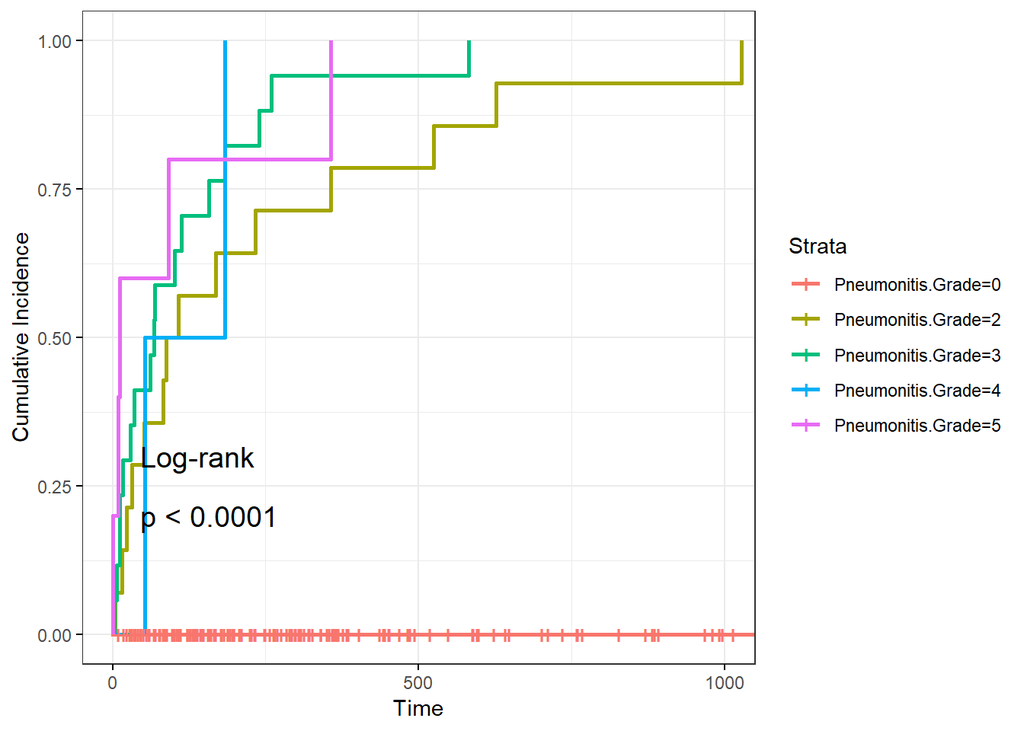

```r
# there is one unknown grade- will remove it for this analysis
CoxPHModel_df <- CoxPHModel_df[CoxPHModel_df$Pneumonitis.Grade < 6,]

# Code Immunotherapy as Nivolumab or Other
CoxPHModel_df$Immunotherapy.Drug.Binary <- lapply(CoxPHModel_df$Immunotherapy.Drug.Recode, function (x) if(x==1) return(1) else return(0))
CoxPHModel_df$Immunotherapy.Drug.Binary <- as.numeric(CoxPHModel_df$Immunotherapy.Drug.Binary)
# Code Histology as Adeno or other
CoxPHModel_df$Histo.Binary <- lapply(factor(CoxPHModel_df$Histology), function (x) if(!is.na(x) & x=="Adenocarcinoma") return(1) else return(0))
CoxPHModel_df$Histo.Binary <- as.numeric(CoxPHModel_df$Histo.Binary)



#--------Cox PH regression for development of pneumonitis - use this to get cumulative incidence------------------------
DvptPneumonitisSfit <- survfit(Surv(PneumonitisOnset, Pneumonitis)~Pneumonitis.Grade, data=CoxPHModel_df)
ggsurvplot(DvptPneumonitisSfit, fun=function(x) {1-x}, xlim=c(0,1000), surv.plot.height=0.5,fontsize=5,legend=c("right"),ylab="Cumulative Incidence",ggtheme=theme_bw(), pval=TRUE, pval.method=TRUE )
```

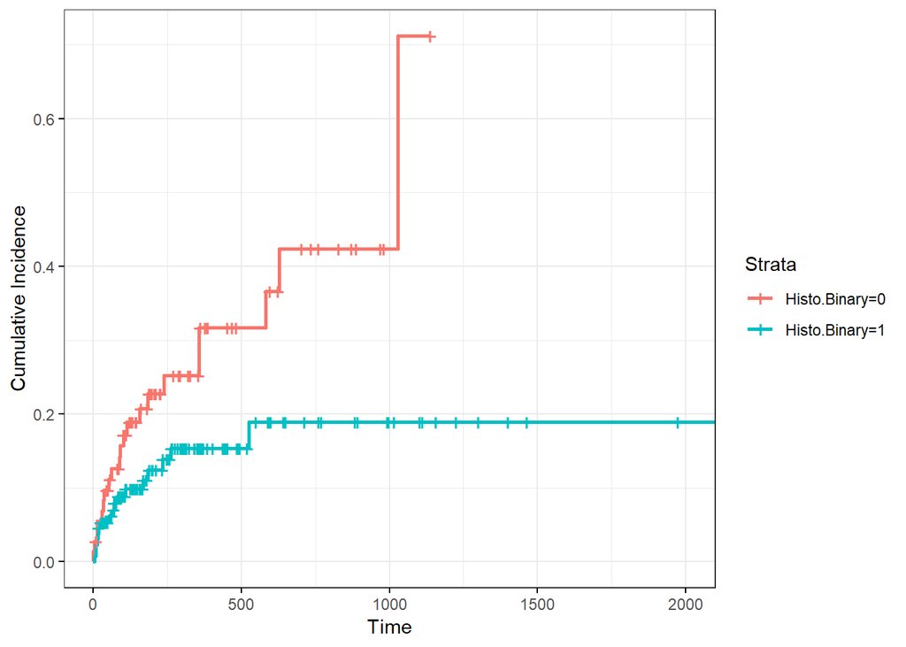

```r
# cum incidence based on histology
DvptPneumonitisSfit_Histo <- survfit(Surv(PneumonitisOnset, Pneumonitis)~Histo.Binary, data=CoxPHModel_df)
ggsurvplot(DvptPneumonitisSfit_Histo, fun=function(x) {1-x},  surv.plot.height=0.5,fontsize=5,legend=c("right"),ylab="Cumulative Incidence",ggtheme=theme_bw())
```

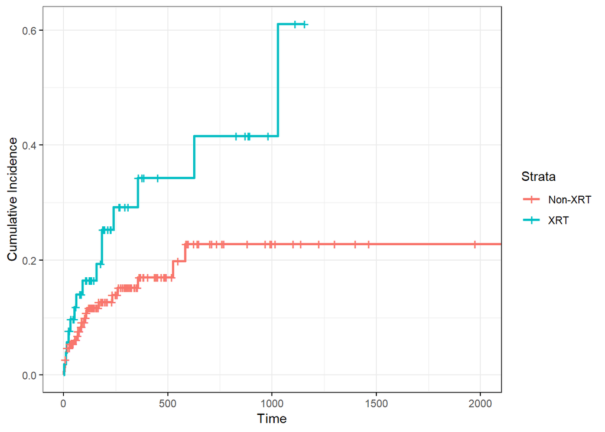

```r
# cum incidence based on radiation
DvptPneumonitisSfit_Rads <- survfit(Surv(PneumonitisOnset, Pneumonitis)~Radiation, data=CoxPHModel_df)
ggsurvplot(DvptPneumonitisSfit_Rads, fun=function(x) {1-x},  surv.plot.height=0.5,fontsize=5,legend=c("right"),ylab="Cumulative Incidence",ggtheme=theme_bw(), legend.labs=c("Non-XRT", "XRT") )
```

```r
# Before we get to the Univariate analysis HR, some assumption testing

# proportionality testing
cox.zph(coxph(Surv(PneumonitisOnset, Pneumonitis) ~ Sex, data=CoxPHModel_df))
```

```
##               rho  chisq     p
## SexFemale -0.0373 0.0525 0.819
```

```r
cox.zph(coxph(Surv(PneumonitisOnset, Pneumonitis) ~ Smoking, data=CoxPHModel_df))
```

```
##           rho chisq     p
## Smoking 0.161 0.812 0.367
```

```r
cox.zph(coxph(Surv(PneumonitisOnset, Pneumonitis) ~ Histology, data=CoxPHModel_df))
```

```
##                     rho chisq     p
## HistologyOther    0.130 0.659 0.417
## HistologySquamous 0.203 1.586 0.208
## GLOBAL               NA 1.763 0.414
```

```r
cox.zph(coxph(Surv(PneumonitisOnset, Pneumonitis) ~ age, data=CoxPHModel_df))
```

```
##        rho chisq     p
## age 0.0967 0.248 0.619
```

```r
cox.zph(coxph(Surv(PneumonitisOnset, Pneumonitis) ~ Race, data=CoxPHModel_df))
```

```
##             rho   chisq     p
## RaceB   0.06216 0.14576 0.703
## RaceO  -0.00677 0.00173 0.967
## GLOBAL       NA 0.15338 0.926
```

```r
cox.zph(coxph(Surv(PneumonitisOnset, Pneumonitis) ~ Initial.Stage, data=CoxPHModel_df))
```

```
##                       rho    chisq     p
## Initial.StageI   9.58e-05 3.39e-07 1.000
## Initial.StageII  1.24e-01 5.61e-01 0.454
## Initial.StageIII 1.25e-01 5.73e-01 0.449
## GLOBAL                 NA 9.15e-01 0.822
```

```r
cox.zph(coxph(Surv(PneumonitisOnset, Pneumonitis) ~ Combination.ICI, data=CoxPHModel_df))
```

```
##                   rho chisq     p
## Combination.ICI 0.217  1.83 0.176
```

```r
cox.zph(coxph(Surv(PneumonitisOnset, Pneumonitis) ~ Chemo, data=CoxPHModel_df))
```

```
##          rho chisq     p
## Chemo -0.127 0.617 0.432
```

```r
cox.zph(coxph(Surv(PneumonitisOnset, Pneumonitis) ~ Surgery, data=CoxPHModel_df))
```

```
##           rho chisq     p
## Surgery 0.204  1.54 0.214
```

```r
cox.zph(coxph(Surv(PneumonitisOnset, Pneumonitis) ~ Immunotherapy.Drug.Recode, data=CoxPHModel_df))
```

```
##                                rho chisq     p
## Immunotherapy.Drug.Recode2  0.0409 0.063 0.802
## Immunotherapy.Drug.Recode3 -0.1483 0.843 0.358
## GLOBAL                          NA 0.924 0.630
```

```r
cox.zph(coxph(Surv(PneumonitisOnset, Pneumonitis) ~ Histo.Binary, data=CoxPHModel_df))
```

```
##                 rho chisq     p
## Histo.Binary -0.204  1.61 0.205
```

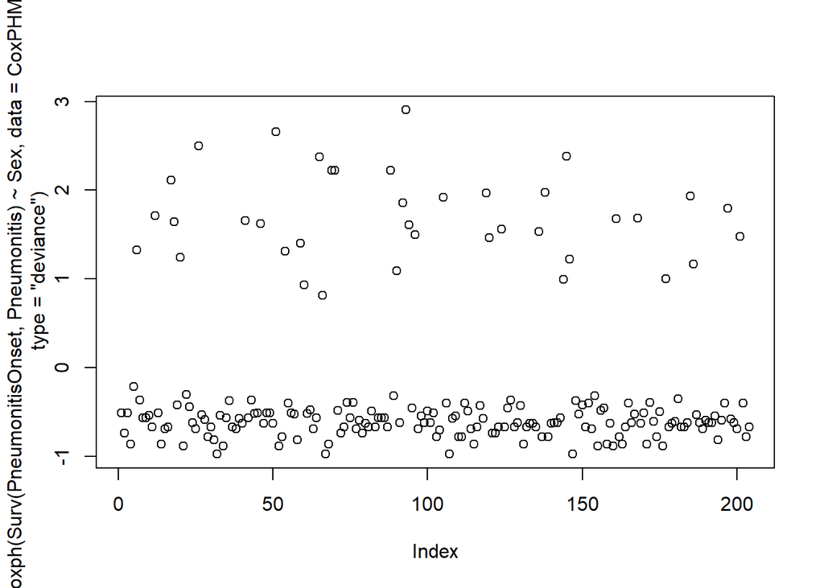

```r
#residuals
plot(resid(coxph(Surv(PneumonitisOnset, Pneumonitis) ~ Sex, data=CoxPHModel_df), type="deviance"))
```

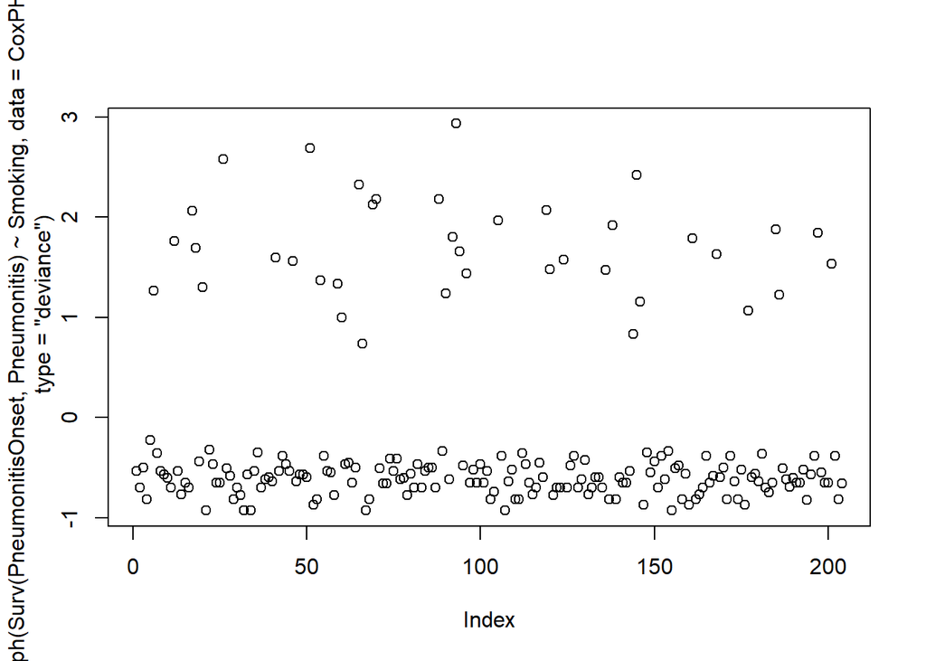

```r
plot(resid(coxph(Surv(PneumonitisOnset, Pneumonitis) ~ Smoking, data=CoxPHModel_df), type="deviance"))
```

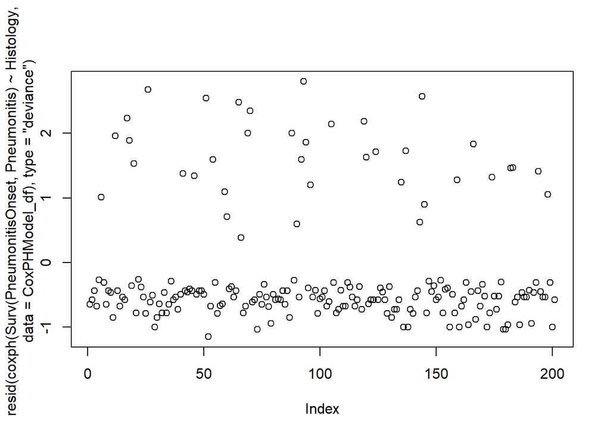

```r
plot(resid(coxph(Surv(PneumonitisOnset, Pneumonitis) ~ Histology, data=CoxPHModel_df), type="deviance"))
```

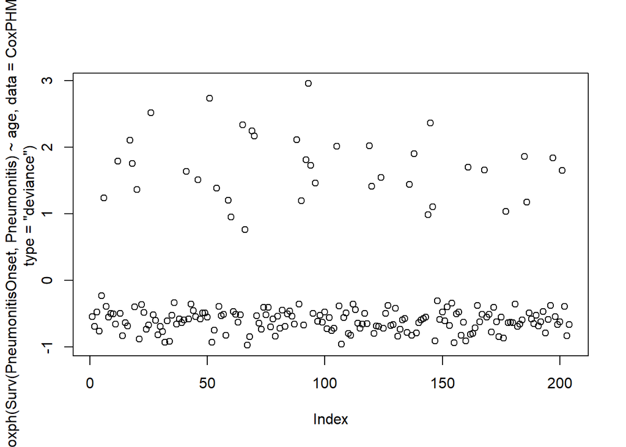

```r
plot(resid(coxph(Surv(PneumonitisOnset, Pneumonitis) ~ age, data=CoxPHModel_df), type="deviance"))
```

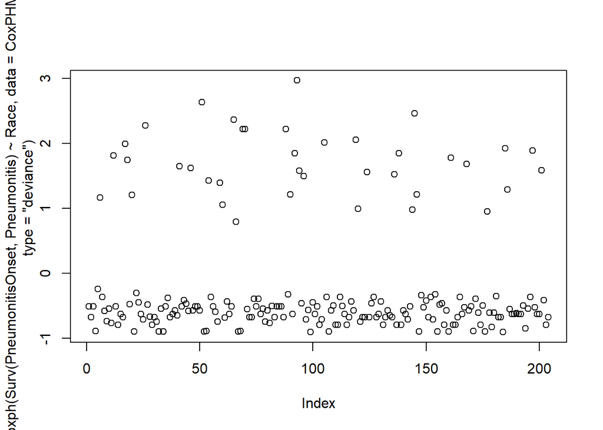

```r
plot(resid(coxph(Surv(PneumonitisOnset, Pneumonitis) ~ Race, data=CoxPHModel_df), type="deviance"))
```

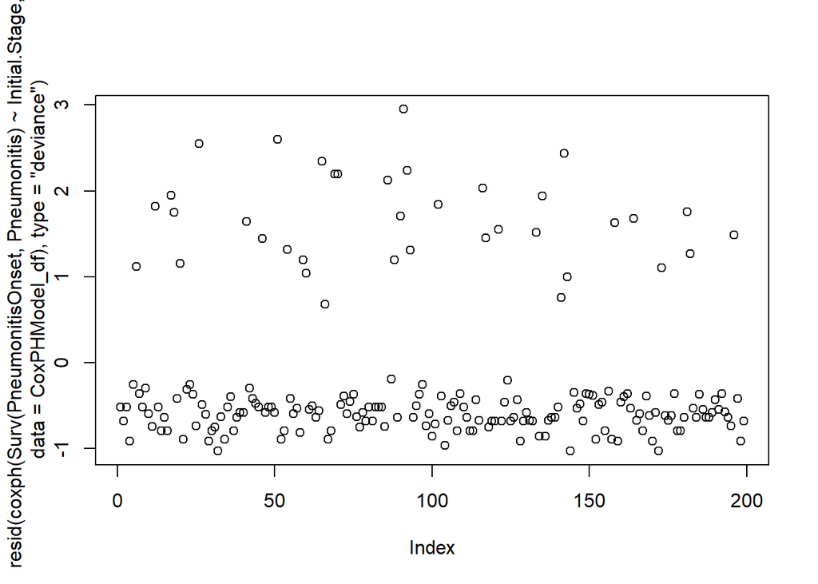

```r
plot(resid(coxph(Surv(PneumonitisOnset, Pneumonitis) ~ Initial.Stage, data=CoxPHModel_df), type="deviance"))
```

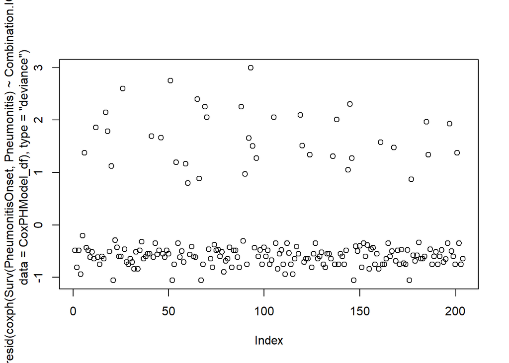

```r
plot(resid(coxph(Surv(PneumonitisOnset, Pneumonitis) ~ Combination.ICI, data=CoxPHModel_df), type="deviance"))
```

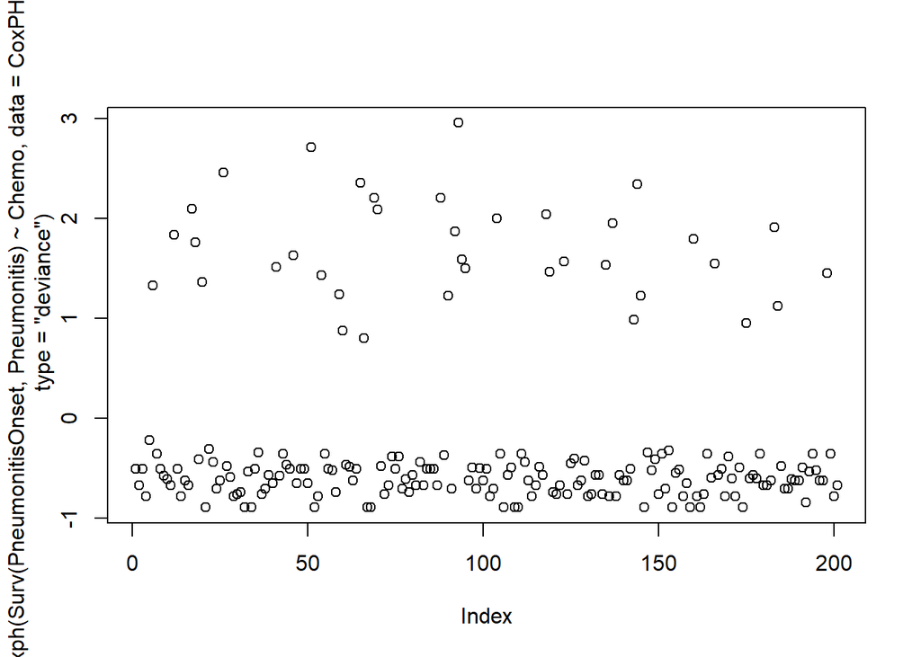

```r
plot(resid(coxph(Surv(PneumonitisOnset, Pneumonitis) ~ Chemo, data=CoxPHModel_df), type="deviance"))
```

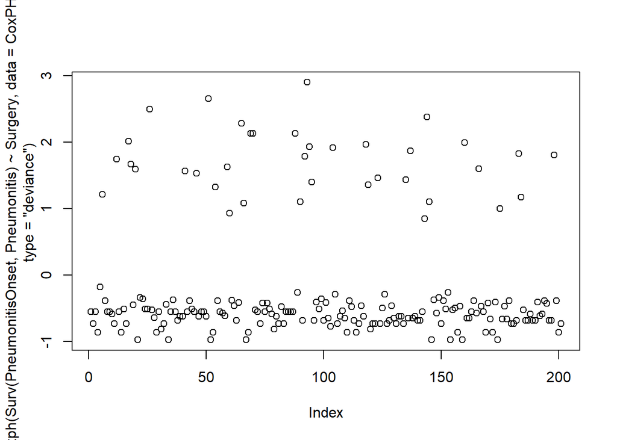

```r
plot(resid(coxph(Surv(PneumonitisOnset, Pneumonitis) ~ Surgery, data=CoxPHModel_df), type="deviance"))
```

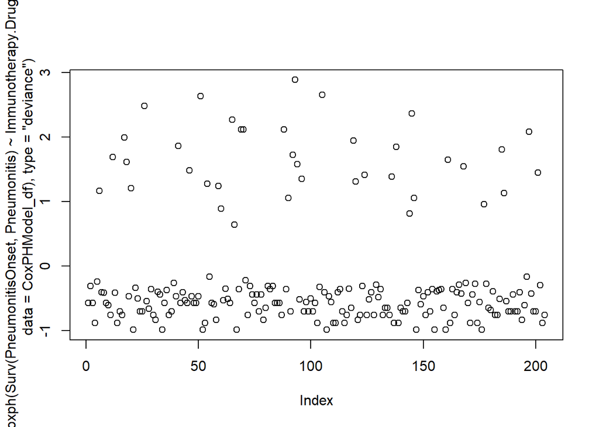

```r
plot(resid(coxph(Surv(PneumonitisOnset, Pneumonitis) ~ Immunotherapy.Drug.Recode, data=CoxPHModel_df), type="deviance"))
```

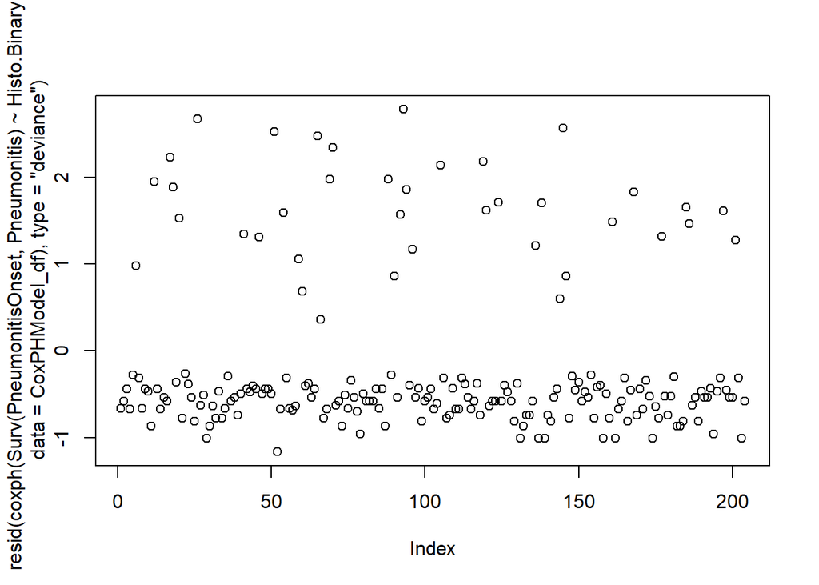

```r
plot(resid(coxph(Surv(PneumonitisOnset, Pneumonitis) ~ Histo.Binary, data=CoxPHModel_df), type="deviance"))
```

```r
# univariate analyses
summary(coxph(Surv(PneumonitisOnset, Pneumonitis) ~ Sex, data=CoxPHModel_df))
```

```
## Call:
## coxph(formula = Surv(PneumonitisOnset, Pneumonitis) ~ Sex, data = CoxPHModel_df)
##
##   n= 204, number of events= 38
##
##             coef exp(coef) se(coef)     z Pr(>|z|)
## SexFemale 0.1997    1.2211   0.3256 0.613     0.54
##
##           exp(coef) exp(-coef) lower .95 upper .95
## SexFemale     1.221      0.819    0.6451     2.311
##
## Concordance= 0.525  (se = 0.044 )
## Rsquare= 0.002   (max possible= 0.834 )
## Likelihood ratio test= 0.37  on 1 df,   p=0.5
## Wald test            = 0.38  on 1 df,   p=0.5
## Score (logrank) test = 0.38  on 1 df,   p=0.5
```

```r
summary(coxph(Surv(PneumonitisOnset, Pneumonitis) ~ Smoking, data=CoxPHModel_df))
```

```
## Call:
## coxph(formula = Surv(PneumonitisOnset, Pneumonitis) ~ Smoking,
##     data = CoxPHModel_df)
##
##   n= 204, number of events= 38
##
##           coef exp(coef) se(coef)    z Pr(>|z|)
## Smoking 0.1220    1.1297   0.3213 0.38    0.704
##
##         exp(coef) exp(-coef) lower .95 upper .95
## Smoking      1.13     0.8852    0.6019     2.121
##
## Concordance= 0.504  (se = 0.04 )
## Rsquare= 0.001   (max possible= 0.834 )
## Likelihood ratio test= 0.14  on 1 df,   p=0.7
## Wald test            = 0.14  on 1 df,   p=0.7
## Score (logrank) test = 0.14  on 1 df,   p=0.7
```

```r
summary(coxph(Surv(PneumonitisOnset, Pneumonitis) ~ Histology, data=CoxPHModel_df))
```

```
## Call:
## coxph(formula = Surv(PneumonitisOnset, Pneumonitis) ~ Histology,
##     data = CoxPHModel_df)
##
##   n= 201, number of events= 38
##    (3 observations deleted due to missingness)
##
##                     coef exp(coef) se(coef)     z Pr(>|z|)
## HistologyOther    1.1658    3.2085   0.5130 2.272   0.0231 *
## HistologySquamous 0.7729    2.1660   0.3492 2.213   0.0269 *
## ---
## Signif. codes:  0 '***' 0.001 '**' 0.01 '*' 0.05 '.' 0.1 ' ' 1
##
##                   exp(coef) exp(-coef) lower .95 upper .95
## HistologyOther        3.209     0.3117     1.174     8.770
## HistologySquamous     2.166     0.4617     1.093     4.294
##
## Concordance= 0.592  (se = 0.043 )
## Rsquare= 0.036   (max possible= 0.837 )
## Likelihood ratio test= 7.34  on 2 df,   p=0.03
## Wald test            = 7.57  on 2 df,   p=0.02
## Score (logrank) test = 8.14  on 2 df,   p=0.02
```

```r
summary(coxph(Surv(PneumonitisOnset, Pneumonitis) ~ age, data=CoxPHModel_df))
```

```
## Call:
## coxph(formula = Surv(PneumonitisOnset, Pneumonitis) ~ age, data = CoxPHModel_df)
##
##   n= 204, number of events= 38
##
##        coef exp(coef) se(coef)     z Pr(>|z|)
## age 0.01172   1.01179  0.01791 0.654    0.513
##
##     exp(coef) exp(-coef) lower .95 upper .95
## age     1.012     0.9883    0.9769     1.048
##
## Concordance= 0.513  (se = 0.051 )
## Rsquare= 0.002   (max possible= 0.834 )
## Likelihood ratio test= 0.43  on 1 df,   p=0.5
## Wald test            = 0.43  on 1 df,   p=0.5
## Score (logrank) test = 0.43  on 1 df,   p=0.5
```

```r
summary(coxph(Surv(PneumonitisOnset, Pneumonitis) ~ Race, data=CoxPHModel_df))
```

```
## Call:
## coxph(formula = Surv(PneumonitisOnset, Pneumonitis) ~ Race, data = CoxPHModel_df)
##
##   n= 204, number of events= 38
##
##         coef exp(coef) se(coef)     z Pr(>|z|)
## RaceB 0.2447    1.2772   0.4229 0.579    0.563
## RaceO 0.7358    2.0871   0.7358 1.000    0.317
##
##       exp(coef) exp(-coef) lower .95 upper .95
## RaceB     1.277     0.7830    0.5576     2.926
## RaceO     2.087     0.4791    0.4934     8.829
##
## Concordance= 0.524  (se = 0.035 )
## Rsquare= 0.005   (max possible= 0.834 )
## Likelihood ratio test= 1.05  on 2 df,   p=0.6
## Wald test            = 1.21  on 2 df,   p=0.5
## Score (logrank) test = 1.26  on 2 df,   p=0.5
```

```r
summary(coxph(Surv(PneumonitisOnset, Pneumonitis) ~ Initial.Stage, data=CoxPHModel_df))
```

```
## Call:
## coxph(formula = Surv(PneumonitisOnset, Pneumonitis) ~ Initial.Stage,
##     data = CoxPHModel_df)
##
##   n= 199, number of events= 37
##    (5 observations deleted due to missingness)
##
##                     coef exp(coef) se(coef)      z Pr(>|z|)
## Initial.StageI   -1.0995    0.3330   1.0264 -1.071    0.284
## Initial.StageII   0.1611    1.1748   0.5525  0.292    0.771
## Initial.StageIII  0.2900    1.3364   0.3602  0.805    0.421
##
##                  exp(coef) exp(-coef) lower .95 upper .95
## Initial.StageI       0.333     3.0027   0.04455     2.490
## Initial.StageII      1.175     0.8512   0.39778     3.470
## Initial.StageIII     1.336     0.7483   0.65961     2.707
##
## Concordance= 0.548  (se = 0.047 )
## Rsquare= 0.014   (max possible= 0.831 )
## Likelihood ratio test= 2.79  on 3 df,   p=0.4
## Wald test            = 2.1  on 3 df,   p=0.6
## Score (logrank) test = 2.31  on 3 df,   p=0.5
```

```r
summary(coxph(Surv(PneumonitisOnset, Pneumonitis) ~ Combination.ICI, data=CoxPHModel_df))
```

```
## Call:
## coxph(formula = Surv(PneumonitisOnset, Pneumonitis) ~ Combination.ICI,
##     data = CoxPHModel_df)
##
##   n= 204, number of events= 38
##
##                   coef exp(coef) se(coef)    z Pr(>|z|)
## Combination.ICI 0.4573    1.5798   0.3291 1.39    0.165
##
##                 exp(coef) exp(-coef) lower .95 upper .95
## Combination.ICI      1.58      0.633    0.8288     3.011
##
## Concordance= 0.531  (se = 0.041 )
## Rsquare= 0.009   (max possible= 0.834 )
## Likelihood ratio test= 1.87  on 1 df,   p=0.2
## Wald test            = 1.93  on 1 df,   p=0.2
## Score (logrank) test = 1.96  on 1 df,   p=0.2
```

```r
summary(coxph(Surv(PneumonitisOnset, Pneumonitis) ~ Chemo, data=CoxPHModel_df))
```

```
## Call:
## coxph(formula = Surv(PneumonitisOnset, Pneumonitis) ~ Chemo,
##     data = CoxPHModel_df)
##
##   n= 201, number of events= 37
##    (3 observations deleted due to missingness)
##
##          coef exp(coef) se(coef)      z Pr(>|z|)
## Chemo -0.2601    0.7710   0.3630 -0.716    0.474
##
##       exp(coef) exp(-coef) lower .95 upper .95
## Chemo     0.771      1.297    0.3785      1.57
##
## Concordance= 0.514  (se = 0.039 )
## Rsquare= 0.002   (max possible= 0.829 )
## Likelihood ratio test= 0.5  on 1 df,   p=0.5
## Wald test            = 0.51  on 1 df,   p=0.5
## Score (logrank) test = 0.52  on 1 df,   p=0.5
```

```r
summary(coxph(Surv(PneumonitisOnset, Pneumonitis) ~ Surgery, data=CoxPHModel_df))
```

```
## Call:
## coxph(formula = Surv(PneumonitisOnset, Pneumonitis) ~ Surgery,
##     data = CoxPHModel_df)
##
##   n= 201, number of events= 37
##    (3 observations deleted due to missingness)
##
##            coef exp(coef) se(coef)      z Pr(>|z|)
## Surgery -0.5727    0.5640   0.4466 -1.282      0.2
##
##         exp(coef) exp(-coef) lower .95 upper .95
## Surgery     0.564      1.773    0.2351     1.353
##
## Concordance= 0.558  (se = 0.038 )
## Rsquare= 0.009   (max possible= 0.829 )
## Likelihood ratio test= 1.86  on 1 df,   p=0.2
## Wald test            = 1.64  on 1 df,   p=0.2
## Score (logrank) test = 1.69  on 1 df,   p=0.2
```

```r
summary(coxph(Surv(PneumonitisOnset, Pneumonitis) ~ Immunotherapy.Drug.Recode, data=CoxPHModel_df))
```

```
## Call:
## coxph(formula = Surv(PneumonitisOnset, Pneumonitis) ~ Immunotherapy.Drug.Recode,
##     data = CoxPHModel_df)
##
##   n= 204, number of events= 38
##
##                               coef exp(coef) se(coef)      z Pr(>|z|)
## Immunotherapy.Drug.Recode2 -0.6489    0.5226   0.7330 -0.885   0.3760
## Immunotherapy.Drug.Recode3 -1.7902    0.1669   1.0148 -1.764   0.0777 .
## ---
## Signif. codes:  0 '***' 0.001 '**' 0.01 '*' 0.05 '.' 0.1 ' ' 1
##
##                            exp(coef) exp(-coef) lower .95 upper .95
## Immunotherapy.Drug.Recode2    0.5226      1.913   0.12424     2.198
## Immunotherapy.Drug.Recode3    0.1669      5.991   0.02284     1.220
##
## Concordance= 0.567  (se = 0.037 )
## Rsquare= 0.031   (max possible= 0.834 )
## Likelihood ratio test= 6.35  on 2 df,   p=0.04
## Wald test            = 3.79  on 2 df,   p=0.2
## Score (logrank) test = 4.71  on 2 df,   p=0.1
```

```r
summary(coxph(Surv(PneumonitisOnset, Pneumonitis) ~ Histo.Binary, data=CoxPHModel_df))
```

```
## Call:
## coxph(formula = Surv(PneumonitisOnset, Pneumonitis) ~ Histo.Binary,
##     data = CoxPHModel_df)
##
##   n= 204, number of events= 38
##
##                 coef exp(coef) se(coef)      z Pr(>|z|)
## Histo.Binary -0.8127    0.4437   0.3272 -2.484    0.013 *
## ---
## Signif. codes:  0 '***' 0.001 '**' 0.01 '*' 0.05 '.' 0.1 ' ' 1
##
##              exp(coef) exp(-coef) lower .95 upper .95
## Histo.Binary    0.4437      2.254    0.2336    0.8425
##
## Concordance= 0.58  (se = 0.042 )
## Rsquare= 0.03   (max possible= 0.834 )
## Likelihood ratio test= 6.18  on 1 df,   p=0.01
## Wald test            = 6.17  on 1 df,   p=0.01
## Score (logrank) test = 6.51  on 1 df,   p=0.01
```

```r
summary(coxph(Surv(PneumonitisOnset, Pneumonitis) ~ Pneumonitis.Grade, data=CoxPHModel_df))
```

```
## Call:
## coxph(formula = Surv(PneumonitisOnset, Pneumonitis) ~ Pneumonitis.Grade,
##     data = CoxPHModel_df)
##
##   n= 204, number of events= 38
##
##                      coef exp(coef) se(coef)     z Pr(>|z|)
## Pneumonitis.Grade 0.99500   2.70472  0.08994 11.06   <2e-16 ***
## ---
## Signif. codes:  0 '***' 0.001 '**' 0.01 '*' 0.05 '.' 0.1 ' ' 1
##
##                   exp(coef) exp(-coef) lower .95 upper .95
## Pneumonitis.Grade     2.705     0.3697     2.268     3.226
##
## Concordance= 0.945  (se = 0.031 )
## Rsquare= 0.437   (max possible= 0.834 )
## Likelihood ratio test= 117.3  on 1 df,   p=<2e-16
## Wald test            = 122.4  on 1 df,   p=<2e-16
## Score (logrank) test = 276.2  on 1 df,   p=<2e-16
```

```r
# multivariate analysis, c and s radiation
summary(coxph(Surv(PneumonitisOnset, Pneumonitis) ~ Histo.Binary+Chemo+Combination.ICI, data=CoxPHModel_df))
```

```
## Call:
## coxph(formula = Surv(PneumonitisOnset, Pneumonitis) ~ Histo.Binary +
##     Chemo + Combination.ICI, data = CoxPHModel_df)
##
##   n= 201, number of events= 37
##    (3 observations deleted due to missingness)
##
##                    coef exp(coef) se(coef)      z Pr(>|z|)
## Histo.Binary    -0.8657    0.4208   0.3337 -2.594  0.00948 **
## Chemo           -0.3507    0.7042   0.3670 -0.955  0.33935
## Combination.ICI  0.5458    1.7259   0.3350  1.629  0.10326
## ---
## Signif. codes:  0 '***' 0.001 '**' 0.01 '*' 0.05 '.' 0.1 ' ' 1
##
##                 exp(coef) exp(-coef) lower .95 upper .95
## Histo.Binary       0.4208     2.3767    0.2188    0.8092
## Chemo              0.7042     1.4200    0.3430    1.4458
## Combination.ICI    1.7259     0.5794    0.8951    3.3279
##
## Concordance= 0.612  (se = 0.05 )
## Rsquare= 0.045   (max possible= 0.829 )
## Likelihood ratio test= 9.23  on 3 df,   p=0.03
## Wald test            = 9.53  on 3 df,   p=0.02
## Score (logrank) test = 9.83  on 3 df,   p=0.02
```

```r
summary(coxph(Surv(PneumonitisOnset, Pneumonitis) ~ Histo.Binary+Chemo+Combination.ICI+Immunotherapy.Drug.Recode, data=CoxPHModel_df))
```

```
## Call:
## coxph(formula = Surv(PneumonitisOnset, Pneumonitis) ~ Histo.Binary +
##     Chemo + Combination.ICI + Immunotherapy.Drug.Recode, data = CoxPHModel_df)
##
##   n= 201, number of events= 37
##    (3 observations deleted due to missingness)
##
##                               coef exp(coef) se(coef)      z Pr(>|z|)
## Histo.Binary               -0.8502    0.4273   0.3331 -2.552   0.0107 *
## Chemo                      -0.3162    0.7289   0.3710 -0.852   0.3940
## Combination.ICI             0.4143    1.5133   0.3405  1.217   0.2237
## Immunotherapy.Drug.Recode2 -1.1845    0.3059   1.0312 -1.149   0.2507
## Immunotherapy.Drug.Recode3 -1.6874    0.1850   1.0182 -1.657   0.0975 .
## ---
## Signif. codes:  0 '***' 0.001 '**' 0.01 '*' 0.05 '.' 0.1 ' ' 1
##
##                            exp(coef) exp(-coef) lower .95 upper .95
## Histo.Binary                  0.4273     2.3401   0.22244     0.821
## Chemo                         0.7289     1.3719   0.35229     1.508
## Combination.ICI               1.5133     0.6608   0.77643     2.950
## Immunotherapy.Drug.Recode2    0.3059     3.2690   0.04053     2.309
## Immunotherapy.Drug.Recode3    0.1850     5.4055   0.02515     1.361
##
## Concordance= 0.648  (se = 0.051 )
## Rsquare= 0.075   (max possible= 0.829 )
## Likelihood ratio test= 15.57  on 5 df,   p=0.008
## Wald test            = 12.94  on 5 df,   p=0.02
## Score (logrank) test = 14.48  on 5 df,   p=0.01
```

```r
# testing
cox.zph(coxph(Surv(PneumonitisOnset, Pneumonitis) ~ Histology+Chemo+Combination.ICI, data=CoxPHModel_df))
```

```
##                      rho chisq     p
## HistologyOther     0.157 0.901 0.343
## HistologySquamous  0.236 2.006 0.157
## Chemo             -0.145 0.741 0.389
## Combination.ICI    0.208 1.476 0.224
## GLOBAL                NA 4.315 0.365
```

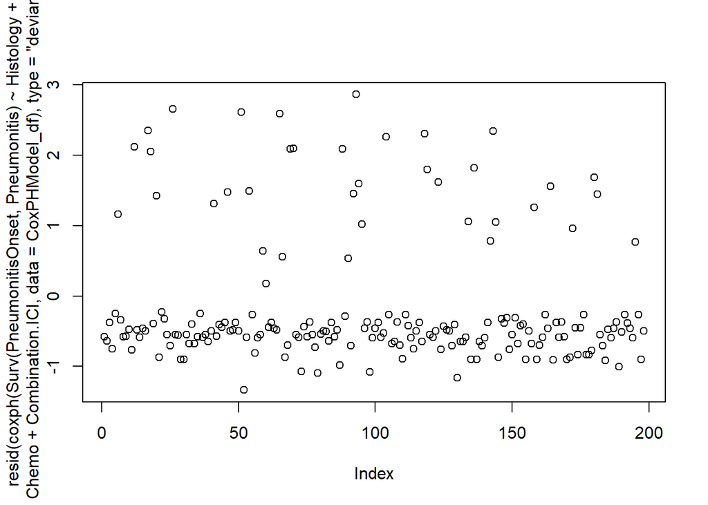

```r
plot(resid(coxph(Surv(PneumonitisOnset, Pneumonitis) ~ Histology+Chemo+Combination.ICI, data=CoxPHModel_df), type="deviance"))
```

## 3. Model B: Logistic regression for development of Pneumonitis at 12 and 24mos.

We develop univariate and multivariate logistic regression models to predict pneumonitis (0,1) at 12 and 24months. Model fit tested using Hosmer-Lebenshow.

```r
# now we'll also do a logistic regression for Pneumonitis
LogitPneum_df <- CoxPHModel_df



# we need new variables for neumonitis at 1,3, 6, 12 months
LogitPneum_df$Pneumonitis.at1mo <- mapply(function(x,y) if(x<30 & y==1) return(1) else return(0), LogitPneum_df$PneumonitisOnset,LogitPneum_df$Pneumonitis)
LogitPneum_df$Pneumonitis.at3mo <- mapply(function(x,y) if(x<90 & y==1) return(1) else return(0), LogitPneum_df$PneumonitisOnset,LogitPneum_df$Pneumonitis)
LogitPneum_df$Pneumonitis.at6mo <- mapply(function(x,y) if(x<180 & y==1) return(1) else return(0), LogitPneum_df$PneumonitisOnset,LogitPneum_df$Pneumonitis)
LogitPneum_df$Pneumonitis.at12mo <- mapply(function(x,y) if(x<360 & y==1) return(1) else return(0), LogitPneum_df$PneumonitisOnset,LogitPneum_df$Pneumonitis)
LogitPneum_df$Pneumonitis.at24mo <- mapply(function(x,y) if(x<720 & y==1) return(1) else return(0), LogitPneum_df$PneumonitisOnset,LogitPneum_df$Pneumonitis)


# univariate analyses for logit at 12  and 24 mo.
# to speed this up, lets use a function
lapply(c("age","Sex","Race", "Smoking", "Histo.Binary", "Initial.Stage", "Combination.ICI", "Chemo", "Surgery", "Immunotherapy.Drug.Recode"),

       function(var) {

           formula    <- as.formula(paste("Pneumonitis.at12mo ~", var))
           res.logist <- glm(formula, data = LogitPneum_df, family = "binomial")
          exp(coef(res.logist))
       })
```

```
## [[1]]
## (Intercept)         age
##   0.1091443   1.0087718
##
## [[2]]
## (Intercept)   SexFemale
##   0.1894737   1.1259260
##
## [[3]]
## (Intercept)       RaceB       RaceO
##   0.1911765   1.0822281   2.0923077
##
## [[4]]
## (Intercept)     Smoking
##   0.2259368   0.8693095
##
## [[5]]
##  (Intercept) Histo.Binary
##    0.3272727    0.4251208
##
## [[6]]
##      (Intercept)   Initial.StageI  Initial.StageII Initial.StageIII
##        0.1847826        0.3382353        1.2488688        1.4431373
##
## [[7]]
##     (Intercept) Combination.ICI
##       0.1652893       1.7285714
##
## [[8]]
## (Intercept)       Chemo
##   0.2195122   0.8608924
##
## [[9]]
## (Intercept)     Surgery
##   0.2222222   0.5357143
##
## [[10]]
##                (Intercept) Immunotherapy.Drug.Recode2
##                  0.2421875                  0.3932412
## Immunotherapy.Drug.Recode3
##                  0.1966206
```

```r
lapply(c("age","Sex","Race", "Smoking", "Histo.Binary", "Initial.Stage", "Combination.ICI", "Chemo", "Surgery", "Immunotherapy.Drug.Recode"),

       function(var) {

           formula    <- as.formula(paste("Pneumonitis.at12mo ~", var))
           res.logist <- glm(formula, data = LogitPneum_df, family = "binomial")
          confint(res.logist)
       })
```

```
## [[1]]
##                   2.5 %     97.5 %
## (Intercept) -5.03661660 0.48475169
## age         -0.03033477 0.04827866
##
## [[2]]
##                  2.5 %     97.5 %
## (Intercept) -2.1994562 -1.1855997
## SexFemale   -0.6281686  0.8584287
##
## [[3]]
##                  2.5 %    97.5 %
## (Intercept) -2.0958574 -1.253268
## RaceB       -0.9778394  1.001453
## RaceO       -1.2414853  2.331692
##
## [[4]]
##                  2.5 %     97.5 %
## (Intercept) -2.2596078 -0.7934861
## Smoking     -0.8705929  0.5993924
##
## [[5]]
##                  2.5 %     97.5 %
## (Intercept)  -1.676698 -0.6054258
## Histo.Binary -1.611121 -0.1091998
##
## [[6]]
##                       2.5 %     97.5 %
## (Intercept)      -2.2402744 -1.1987185
## Initial.StageI   -4.0090632  0.6078362
## Initial.StageII  -1.3236226  1.4813464
## Initial.StageIII -0.4719303  1.1821887
##
## [[7]]
##                      2.5 %    97.5 %
## (Intercept)     -2.3026290 -1.351245
## Combination.ICI -0.2271205  1.301964
##
## [[8]]
##                  2.5 %     97.5 %
## (Intercept) -2.3030480 -0.8422099
## Chemo       -0.9658705  0.7377220
##
## [[9]]
##                 2.5 %     97.5 %
## (Intercept) -1.933051 -1.1108241
## Surgery     -1.752213  0.3154966
##
## [[10]]
##                                2.5 %       97.5 %
## (Intercept)                -1.827512 -1.040006857
## Immunotherapy.Drug.Recode2 -2.798881  0.364722091
## Immunotherapy.Drug.Recode3 -4.531508 -0.002329009
```

```r
lapply(c("age","Sex","Race", "Smoking", "Histo.Binary", "Initial.Stage", "Combination.ICI", "Chemo", "Surgery", "Immunotherapy.Drug.Recode"),

       function(var) {

           formula    <- as.formula(paste("Pneumonitis.at12mo ~", var))
           res.logist <- glm(formula, data = LogitPneum_df, family = "binomial")
          summary(res.logist)
       })
```

```
## [[1]]
##
## Call:
## glm(formula = formula, family = "binomial", data = LogitPneum_df)
##
## Deviance Residuals:
##     Min       1Q   Median       3Q      Max
## -0.6657  -0.6176  -0.5982  -0.5741   1.9556
##
## Coefficients:
##              Estimate Std. Error z value Pr(>|z|)
## (Intercept) -2.215084   1.401625  -1.580    0.114
## age          0.008734   0.019955   0.438    0.662
##
## (Dispersion parameter for binomial family taken to be 1)
##
##     Null deviance: 183.83  on 203  degrees of freedom
## Residual deviance: 183.64  on 202  degrees of freedom
## AIC: 187.64
##
## Number of Fisher Scoring iterations: 4
##
##
## [[2]]
##
## Call:
## glm(formula = formula, family = "binomial", data = LogitPneum_df)
##
## Deviance Residuals:
##     Min       1Q   Median       3Q      Max
## -0.6219  -0.6219  -0.5891  -0.5891   1.9168
##
## Coefficients:
##             Estimate Std. Error z value Pr(>|z|)
## (Intercept)  -1.6635     0.2571  -6.471 9.72e-11 ***
## SexFemale     0.1186     0.3767   0.315    0.753
## ---
## Signif. codes:  0 '***' 0.001 '**' 0.01 '*' 0.05 '.' 0.1 ' ' 1
##
## (Dispersion parameter for binomial family taken to be 1)
```

[output cut: 198 more lines]

```
## Coefficients:
##                            Estimate Std. Error z value Pr(>|z|)
## (Intercept)                 -1.4180     0.2002  -7.084  1.4e-12 ***
## Immunotherapy.Drug.Recode2  -0.9333     0.7666  -1.217    0.223
## Immunotherapy.Drug.Recode3  -1.6265     1.0428  -1.560    0.119
## ---
## Signif. codes:  0 '***' 0.001 '**' 0.01 '*' 0.05 '.' 0.1 ' ' 1
##
## (Dispersion parameter for binomial family taken to be 1)
##
##     Null deviance: 183.83  on 203  degrees of freedom
## Residual deviance: 178.61  on 201  degrees of freedom
## AIC: 184.61
##
## Number of Fisher Scoring iterations: 5
```

```r
lapply(c("age","Sex","Race", "Smoking", "Histo.Binary", "Initial.Stage", "Combination.ICI", "Chemo", "Surgery", "Immunotherapy.Drug.Recode"),

       function(var) {

           formula    <- as.formula(paste("Pneumonitis.at24mo ~", var))
           res.logist <- glm(formula, data = LogitPneum_df, family = "binomial")
           summary(res.logist)
           exp(coef(res.logist))
           confint(res.logist)
       })
```

```
## [[1]]
##                   2.5 %     97.5 %
## (Intercept) -5.00997503 0.34438689
## age         -0.02673438 0.04938809
##
## [[2]]
##                  2.5 %     97.5 %
## (Intercept) -2.1217875 -1.1300349
## SexFemale   -0.5201621  0.9152858
##
## [[3]]
##                  2.5 %    97.5 %
## (Intercept) -1.9926669 -1.174929
## RaceB       -0.8092161  1.061531
## RaceO       -1.3283772  2.239307
##
## [[4]]
##                  2.5 %     97.5 %
## (Intercept) -2.3177667 -0.8558106
## Smoking     -0.6620415  0.7690145
##
## [[5]]
##                  2.5 %     97.5 %
## (Intercept)  -1.512008 -0.4772510
## Histo.Binary -1.662448 -0.2061154
##
## [[6]]
##                       2.5 %     97.5 %
## (Intercept)      -2.0798552 -1.0843880
## Initial.StageI   -4.1396295  0.4656184
## Initial.StageII  -1.4509675  1.3370796
## Initial.StageIII -0.4728281  1.1228994
##
## [[7]]
##                       2.5 %    97.5 %
## (Intercept)     -2.23430502 -1.302219
## Combination.ICI -0.07747694  1.396429
##
## [[8]]
##                 2.5 %     97.5 %
## (Intercept) -1.984005 -0.6318829
## Chemo       -1.128930  0.4738418
##
## [[9]]
##                 2.5 %     97.5 %
## (Intercept) -1.789026 -0.9983957
## Surgery     -1.873471  0.1815990
##
## [[10]]
##                                2.5 %     97.5 %
## (Intercept)                -1.696078 -0.9353607
## Immunotherapy.Drug.Recode2 -2.912875  0.2437838
## Immunotherapy.Drug.Recode3 -4.646384 -0.1225124
```

```r
Pneum_glm.12mo <- glm(Pneumonitis.at12mo ~ Histo.Binary+Combination.ICI+Immunotherapy.Drug.Binary, data=LogitPneum_df, family="binomial")

lapply(c("age","Sex","Race", "Smoking", "Histo.Binary", "Initial.Stage", "Combination.ICI", "Chemo", "Surgery", "Immunotherapy.Drug.Recode"),

       function(var) {

           formula    <- as.formula(paste("Pneumonitis.at24mo ~", var))
           res.logist <- glm(formula, data = LogitPneum_df, family = "binomial")
          summary(res.logist)
       })
```

```
## [[1]]
##
## Call:
## glm(formula = formula, family = "binomial", data = LogitPneum_df)
##
## Deviance Residuals:
##     Min       1Q   Median       3Q      Max
## -0.7145  -0.6506  -0.6251  -0.5884   1.9277
##
## Coefficients:
##             Estimate Std. Error z value Pr(>|z|)
## (Intercept) -2.27410    1.35934  -1.673   0.0943 .
## age          0.01105    0.01932   0.572   0.5674
## ---
## Signif. codes:  0 '***' 0.001 '**' 0.01 '*' 0.05 '.' 0.1 ' ' 1
##
## (Dispersion parameter for binomial family taken to be 1)
##
##     Null deviance: 193.18  on 203  degrees of freedom
## Residual deviance: 192.85  on 202  degrees of freedom
## AIC: 196.85
##
## Number of Fisher Scoring iterations: 4
##
##
## [[2]]
##
## Call:
## glm(formula = formula, family = "binomial", data = LogitPneum_df)
##
## Deviance Residuals:
##     Min       1Q   Median       3Q      Max
## -0.6639  -0.6639  -0.6068  -0.6068   1.8884
##
## Coefficients:
##             Estimate Std. Error z value Pr(>|z|)
## (Intercept)  -1.5989     0.2515  -6.356 2.07e-10 ***
## SexFemale     0.1988     0.3640   0.546    0.585
## ---
## Signif. codes:  0 '***' 0.001 '**' 0.01 '*' 0.05 '.' 0.1 ' ' 1
```

[output cut: 200 more lines]

```
## Coefficients:
##                            Estimate Std. Error z value Pr(>|z|)
## (Intercept)                 -1.3020     0.1934  -6.731 1.68e-11 ***
## Immunotherapy.Drug.Recode2  -1.0494     0.7649  -1.372   0.1701
## Immunotherapy.Drug.Recode3  -1.7426     1.0415  -1.673   0.0943 .
## ---
## Signif. codes:  0 '***' 0.001 '**' 0.01 '*' 0.05 '.' 0.1 ' ' 1
##
## (Dispersion parameter for binomial family taken to be 1)
##
##     Null deviance: 193.18  on 203  degrees of freedom
## Residual deviance: 186.77  on 201  degrees of freedom
## AIC: 192.77
##
## Number of Fisher Scoring iterations: 5
```

```r
Pneum_glm.24mo <- glm(Pneumonitis.at24mo ~ Histo.Binary+Combination.ICI+Immunotherapy.Drug.Binary, data=LogitPneum_df, family="binomial")

# how good are these models above? We will evaluate this with: Hosmer-Lemeshow

library(lmtest)
hoslem.test(LogitPneum_df$Pneumonitis.at12mo, fitted(Pneum_glm.12mo))
```

```
##
##  Hosmer and Lemeshow goodness of fit (GOF) test
##
## data:  LogitPneum_df$Pneumonitis.at12mo, fitted(Pneum_glm.12mo)
## X-squared = 1.2198, df = 8, p-value = 0.9964
```

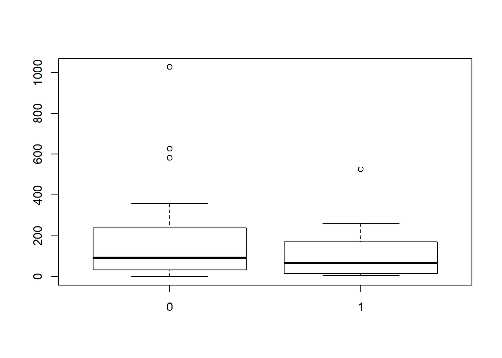

```r
LogitPneum_df_CIPOnly <- LogitPneum_df[LogitPneum_df$Pneumonitis==1,]

# In the Non-squamous cell Nivo trial in the NEJM, 7/287 patients developed CIP. In the Squamous trial, 6/131 developed pneumonitis
# if this relationship between histology type and pneumonitis onset is true, we should see a shift in the cdf(PneumonitisOnset) when split by histology type in Pneumonitis+ pts?

boxplot(PneumonitisOnset~Histo.Binary, data=LogitPneum_df_CIPOnly)
```

```r
d0 <- as.data.frame(LogitPneum_df_CIPOnly[LogitPneum_df_CIPOnly$Histo.Binary==0,]$PneumonitisOnset)
 d1 <- as.data.frame(LogitPneum_df_CIPOnly[LogitPneum_df_CIPOnly$Histo.Binary==1,]$PneumonitisOnset)

# ggplot() + stat_density(aes(x=d1, fill=1,color="Adenocarcinoma", n=1028), data=d1, alpha=0.1)+stat_density(aes(x=d0, fill=2,color="Non-AC"), data=d0, alpha=0.1,n=1028)+labs(x="Onset of Pneumonitis (days)", y="Density")+theme(legend.position="bottom")
```